# Is It Drift?

## The Goal of this R Markdown is to determine if the increase in the Newt and Snake phenotypes is caused by drift

Background:

In the newts and snakes 1on1 simulations I noticed that the mean phenotype of newts and snakes increased at a steady rate. If the mean newt phenotype was higher than the mean snake phenotype at the beginning of the simulation, it would still be higher at the end of the simulation. This is somewhat expected, because its better for the newts to be more toxic than the snakes can handle. To be able to eat the newts, snakes need to increase their resistance. It makes since that both of the phenotypes increased, but it is weird that they never seemed to cross. It is also possible that these phenotypes increase because of drift.

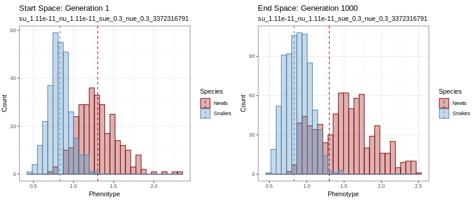

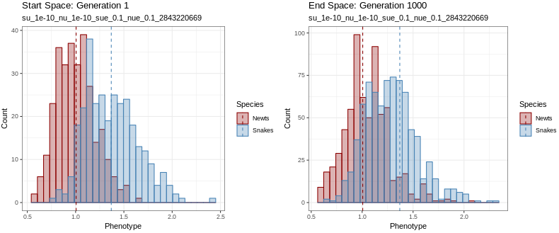

 I also noticed the distribution of newt and snake phenotypes were different between the under 5 and under 2 simulations. The under 2 were more normal while the under 5 had a long right tail. If I use the values for under 5 I could get more extreme phenotypes for some newts or snakes.

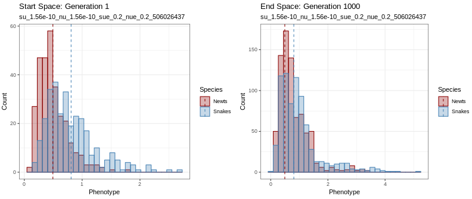

u5 distribution

These observations lead me to ask, is drift causing the the mean of the higher phenotype to stay higher or is it selection? To attempt to answer this question I will look at two things. 1 How many newts kill snakes (and vice-versa). 2 What would happen if there were no mutations (no genetic variation) and an artificial (beneficial) mutation was released into the population.

## The Newt and Snake Interaction

I have the mean amount and sd of newts and snakes that have been eaten by the opposite species. This info will hopefully give me an idea on how the newts and snakes are interacting.

Important things to look at: mean_newts_eaten and mean_snakes_eaten (mean of #eaten/age) sd_newts_eaten and sd_snakes_eaten (sd of #eaten/age) Newt_pop_size and Snake_pop_size Newt_density and Snake_density

To make sure my simulations are working correctly, I am going to graph the mean and standard deviation of newt and snake phenotypes by generation. I expect the mean phenotype to increase as the number of generations increase (because it has in the other simulations). I will also graph the mean and standard deviation of the number of newts and snakes eaten by the other species (color indicates species that was killed). I predict that number of newts/snakes killed by the other species to increase as the number of generations increases (similar to what the phenotypes do). I also predict that the standard deviation of how many newts and snakes are killed by the other species to increase as the number of generations increases. This thought stems from the idea that the higher a phenotype on individual the more likely this individual will eat more of the other species. Although, this thought might be flawed if one species has a higher phenotype it is possible for 2 things to happen; 1 the other species may also have a high phenotype limiting the chance for successful encounters, or 2 if the species (and its’ family & friends) has too high of a phenotype there might not be any of the opposite species around.

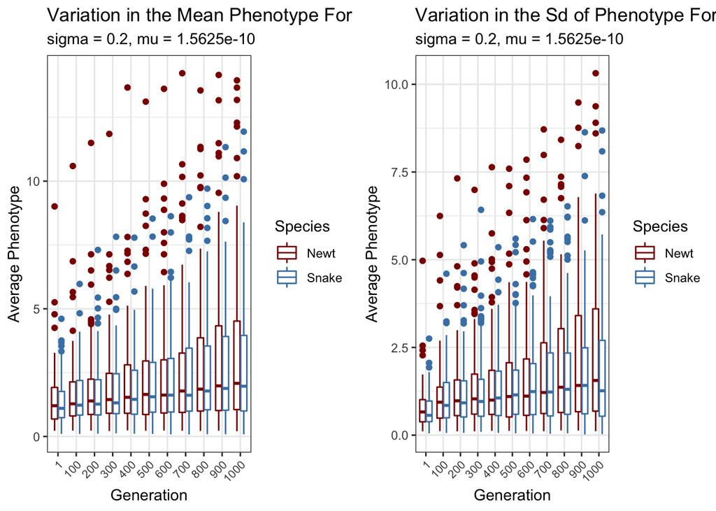

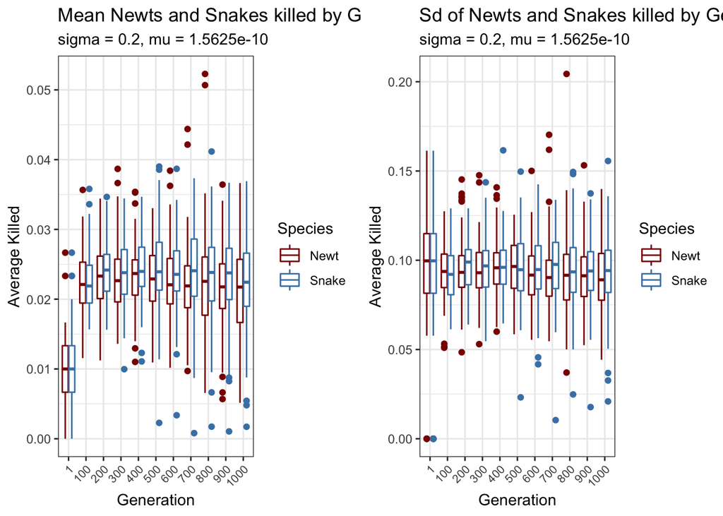

To get a better mental image of whats going on with the interaction I will plot density by newts/snakes killed, phenotype by newts/snakes killed, and population size by newts/snakes killed. I predict the density and population size plots should be very similar. I expect that a higher population size = higher density. I predict that as the density/population size increase the number of newts and snakes killed by the other species will increase. I would hope that phenotype by newts/snakes killed would also show an increasing pattern, as the phenotypes got larger the more newts and snakes would be killed. But since it did not look that way in the generation plot, I predict that there is no change in the amount of newts and snakes killed.

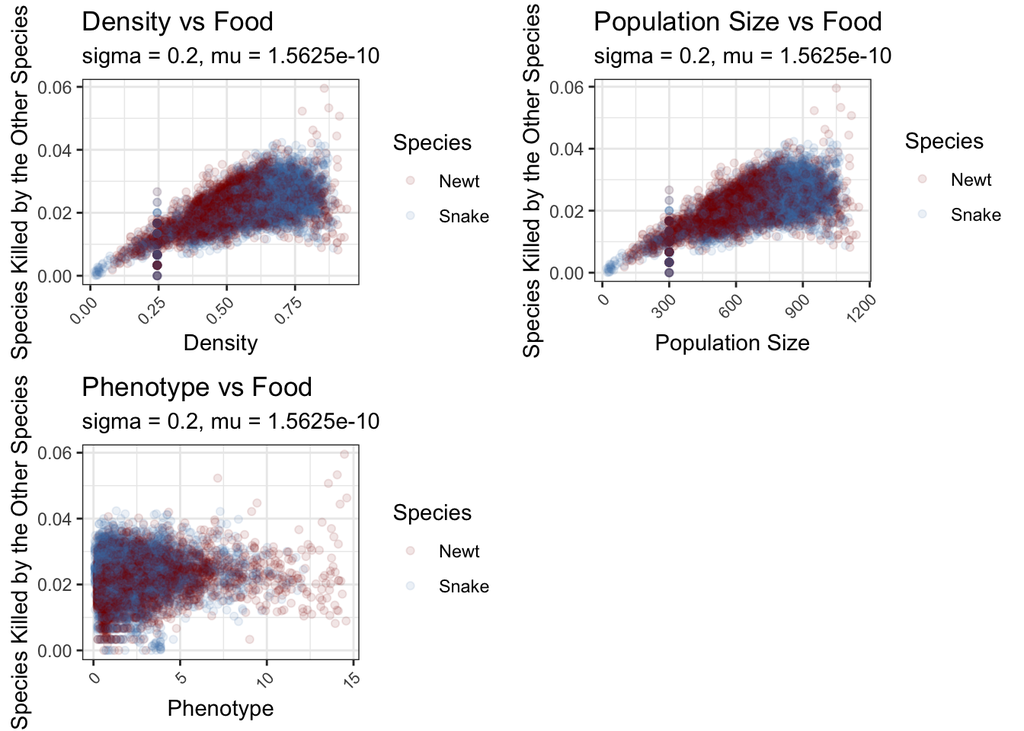

After plotting these three figures I noticed that density and population size are the same (weird I thought they would be similar not exact). There is a bit of confusion that I had when looking at these plots due to the color. Red is not only the newt density/population size/phenotype, it is also the amount of newts killed. The blue points represent the snake density/population size/phenotype and the amount of snakes killed. (Might refer to them as “newt deaths” and “snake deaths”) They do show the trend I was expecting; higher density = more interactions. What I did not expect was the separation of color, newts seem to have lower population sizes and densities, while snakes had a higher population size and density. The strait line at 300 and .25 is from the simulations starting points. I found it weird that the data gets nosier as the population size/density gets to its highest point. Also it looks like the amount of newts and snakes killed by the other species decreases when the population density is over 0.75. Could this be due to one species having a low amount of individuals?

The phenotype vs food is a mess. I am having a lot of trouble seeing a potential trend. Maybe the way I chose to color the points is making this more difficult. There probably is no trend. It seems like there is no correlation between phenotype and ability to kill the the other species. It might be better to look at an individuals’ fitness and its ability not to die, in order to determine if having a higher phenotype is beneficial.

## What About The Difference between Phenotypes??

It is possible that there might be an interaction between the phenotypes of newts and snakes and the amount of newts and snakes killed by the opposite species. To see if there might be a rough interaction I will look at the difference between the mean snake and the mean newt phenotype (snakes-newts) and the amount of individuals killed by the other species per year they have been alive. I predict that when the phenotypess are similar there will be an equal amount of newts and snakes killed. When the phenotypes are different I will predict that the species with the higher phenotype will be killed less.

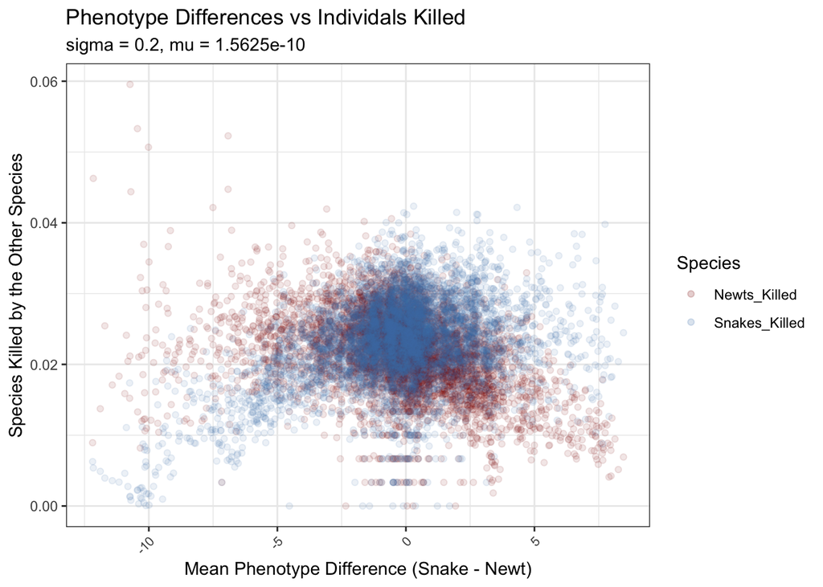

This is the opposite of what I thought would occur. So much so I am triple checking the code. This figure makes it seem like there are more snakes killed the higher the snake phenotype is. Or there are less newts killed the higher the phenotype for the snake. Maybe this is an indication that newts and snakes are competing so that there are area of high resistance and areas of high toxicity which can cancel each other out but still produce a high mean phenotype? This seems very weird to me! I would need to look at the difference between individuals phenotypes based on their locations and then see where the killed values are coming from. Very strange result.

## Is it Coevolution

I predict that the mutation will increase and spread through out the population in some, but not all of the populations. But at what point is it drift? or is it selection? What fraction are we looking for?

Starting parameters:

- sigma_i = 1,
- recomb=1e-8,
- sigma_in = 0.5,
- **sigma_M = 0.33**,
- **K =1**,
- SD = sigma_in,
- SI = sigma_in,
- surs = sigma_in,
- SM = SI,
- L = 4,
- W = 35.0,
- G = 1e8,
- FECUN = 1/(L)),
- RHO = FECUN/((1+FECUN) * K),
- initializeRecombinationRate(recomb)

Interaction Constants:

- **interaction_rate = 0.05**,
- PE = 0.1,
- w = 10,
- c = 0.0,
- **some_value = 30 (half number of new individuals)**,
- **sc_size = 10 (selection coefficient)**

I bolded things that I thought might have an impact on if the mutation would spread

### Newts Get the Mutation

| Notes | Yes | No |
| --- | --- | --- |
| Newts | 16 | 84 |
| interaction rate = 0.07 | 18 | 82 |
| sigma_M = 0.4 | 22 | 78 |
| sc_size = 0.5 | 6 | 94 |
| sc_size = 15, some value = 60 | 32 | 68 |

Seems like having more individuals and a higher selection coefficient lead to the mutation spreading to all of the individuals in the population. For most of the simulations the spreading out or dying out happens very quickly (under 1500 generations)

###Snakes Get the Mutation

| Notes | Yes | No |
| --- | --- | --- |
| Snakes | 14 | 86 |
| interaction rate = 0.5 | 20 | 80 |
| sigma_M = 0.4 | 8 | 92 |
| sc_size = 0.5 | 0 | 100 |
| sc_size = 15, some value = 60 | 38 | 62 |

This is also the case when snakes get the mutation. Although it was peculiar when the selection coefficient was very small there were no cases when the artificial mutation spread throughout the population.

###Both Newts and Snakes get the Mutation

| Notes | Snake_Yes | Newt_Yes | Snake_No | Newt_No |
| --- | --- | --- | --- | --- |
| sc_size = 15, some vaalue = 60 | 30 | 30 | 70 | 70 |

When both species get the mutation I saw each combination happen sometimes the mutation would spread in both the snakes and newts populations. Other times only the mutation would only spread in one population and there were time when the mutation dies out in both populations.

Concluding notes:

The artificial mutation either stays in the population increasing rapidly or dies out in a few generations, suggesting that the mutation is spreading due to selection. The mutation does spread do to selection, but I think it can be quicker and I am not sure if it is due to the interaction between snakes and newts. I want to increase the rate of the interaction without creating areas where newts and snakes don’t interact (holes). I also want to test the prediction that a higher phenotype might protect an individual from death. First, I will look at the correlation between phenotype and fitness (a measure of how likely an individual will survive) and see if they are positively or negatively correlated. However, there might be problems crease by spatial structure that might impact the correlation. So, the second thing I will do is crease and run a no space simulation to see the direct consequence the interaction had on individuals phenotypes. The only problem is determining how many newt and snakes will be interacting with each other?